# CSC-496/696: Natural Language Processing and Text as Data

Lecture 12: Word Embeddings Applications

Patrick Wu

Tuesday, October 15, 2024

## Announcements

- Assignment 3 will be posted today
- Information about the final project will be released on Friday
- It will largely be the same information as what’s found on the syllabus

## Final Project

- You will have the choice to propose your own research project, or you can complete a task related to a dataset I will assign
- Meet with me early if you want to want to get ideas for a research project—I’m happy to help with formulating research questions, getting datasets, etc.

## Rest of the Course

- We have now covered a lot of ground in terms of the basics of NLP
- As we move into more modern techniques (such as those developed in the last 10 years), we’ll increasingly think about how we can use it to solve problems we might be interested in

## Training Word Embeddings in Python

Now we’ll move over to the lab to look at how we can train word embeddings

## Review of Word Embeddings

- Quantifying meaning for individual words
- Want a way to quantify “closeness” and “farness” of word meanings
- We’ll do this using an embedding space, where words are vectors in a vector space

## Review of Word Embeddings

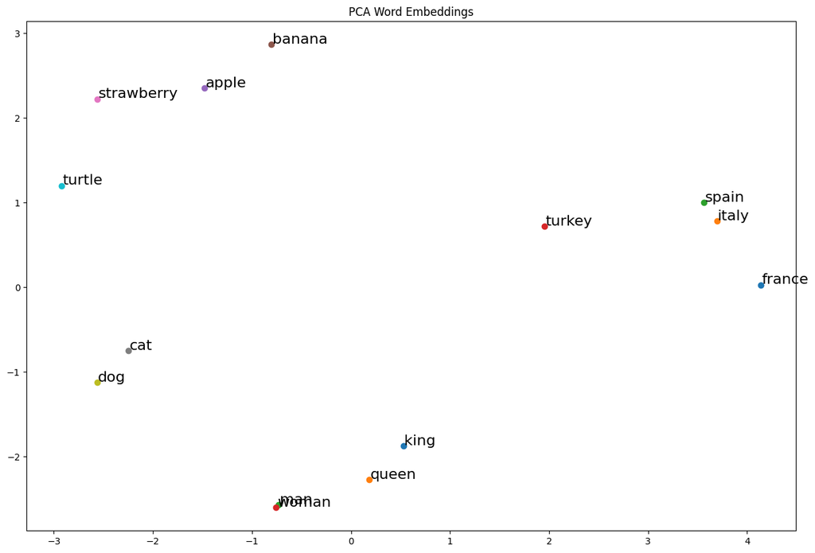

Any questions before we move on?

We’ll now look at how we can calculate word embeddings in Python

The Colab link can be found [here](https://colab.research.google.com/drive/1A3ViftZL73qiYBNafnfzdeXWpyBkoG6k?usp=sharing)

## Application: Partisan Associations

- Paper can be found [here](https://www.patrickywu.com/working_papers/partisanassociations_wumebanewoodsklaverdue_apsa2019.pdf)
- A paper that I worked on while doing my PhD
- Problem: existing methods of measuring partisanship looked at explicitly political behavior
  - Following/Follower behavior
  - Tweeting at political actors
- Requires an *abundance* of this type of behavior
  - Following at least 8 political actors or entities

Bios contain a lot of information

[figure not shown]

- **Idea**: some people have explicitly partisan information or affiliations in their bios, but others do not
- People who explicitly affiliate themselves with a party or political candidate also often include other interests, hobbies, affiliations, etc.
- There are then other people who do not include political affiliations, but do include overlapping interests, hobbies, affiliations, etc.
- Certain activities, hobbies, identities, etc. tend to be in the contextual neighborhoods of explicit partisan affiliations!
- How do we learn these associations that bridge across words?
- Rather than trying to learn explicit relationships between words, we can use word2vec to automatically learn the relationships between words
- In the paper, we use a technique called *doc2vec*, which is very similar to word2vec
- Instead of averaging the word embeddings of a document, we use a unique document ID to predict the words in a document
- We mapped every word to an embedding and we mapped every document to an embedding
- This was all in the same embedding space
- Recall that Mikolov et al. (2013) found

$$\vec{\text{king}} - \vec{\text{man}} + \vec{\text{woman}} \approx \vec{\text{queen}}$$

- With some simple rearranging, we get

$$\vec{\text{king}} - \vec{\text{queen}} \approx \vec{\text{man}} - \vec{\text{woman}}$$

- We observe that this is a kind of *gender* subspace in the word embedding space
- So in theory, for the 2016 U.S. election,

$$\vec{\text{trump}} - \vec{\text{clinton}} \approx \vec{\text{republican}} - \vec{\text{democrat}}$$

- We took the difference between the average of several Republican keywords and several Democratic keywords
- We then took the cosine similarity between each bio’s embedding and this partisan subspace
- The higher the cosine similarity, the more Republican-leaning the bio (falls closer to the Republican end of the subspace)
- The lower the cosine similarity, the more Democratic-leaning the bio (falls closer to the Democratic end of the subspace)
- We called this each user’s *partisan association score*
- We found that this partisan association score highly correlates with political behaviors such as retweeting or tweeting at specific politicians, the use of partisan hashtags, and who the user follows

## End of Class Activity

- Imagine you had access to any text corpus, and you used word2vec to obtain embeddings of the words (and documents)
- What research question would you answer using word embeddings?
- I want you to pair up (or in groups of 3) and discuss this
- In the last 10 minutes of class, we’ll go around and discuss what people come up with